# motus_receiver_data

Patrick D. lorch

2023-08-27

Before running this code you should run the motus_project_data to get the data downloaded into local .motus database files. Then you can just connect to them here.

## Signal Strength Plots

Have a look at detection data colored by antenna direction. NA usually is for an omni.

The data in the setup block on tags is generally determined from the motus.org website. For example, when you see new tags have been detected at one of your stations, you mark the date or range, Motus tag ID, and project. Then you set those things here and do some plotting.

For now we run one tag at a time. If you are going to use Knitter, comment out all but one in the setup block below.

```r
library(motus)
library(lubridate)
library(dplyr)
```

```r
Sys.setenv(TZ = "UTC")
library(ggplot2)

# Project
# California Department of Fish and Wildlife Motus (#446)
proj.num = 446

## Connect to existing .motus
proj.sql.motus <- tagme(projRecv = proj.num, new = FALSE, update = FALSE)

# Focal receiver (from df.projRecvs in rectag block below)
#    stationID        stationName            serno
# 1      10593     Grizzly Island CTT-4C1B6DEFDC5C
# 2      10616        Yolo Bypass CTT-61546A685C2C
# 3      10639       Eden Landing CTT-E56F9EF340B6
# 4      12431     Elkhorn Slough CTT-3D35D88BF546
# 5      12459        Salt Slough CTT-B9683CBEE57C
# 6      12617         Llano Seco CTT-D818FFEDB922
# 7      12723        San Jacinto CTT-1CBEBDA79D53
# 8      13040         Palo Verde CTT-39A7525A06F7
# 9      13041           Imperial CTT-8B07B0305758
# 10     13310          Camp Cady CTT-V30B0154E4B7
# 11     13387 Indian Joe Springs             <NA>

focal_rec_id = 13310 # Use a stationID

## Recievers
# Set which stations data to use
# Camp Cady
rec_id_camp_cady = "CTT-V30B0154E4B7"
# Indian Joe
rec_id_indian_joe = "CTT-V30B0154C892"

# Tags detected by CDFW stations
# YBCU
# Hummus
tag_motus_id = 60762
tag = "Hummus (60762)"
file_name_prefix = "Yellow-billed Cuckoo Hummus"
(time_range = as.POSIXct(c("2023-08-09", "2023-08-09")))
```

```
## [1] "2023-08-09 UTC" "2023-08-09 UTC"
```

```r
# WETA
# tag_motus_id = 76180
# tag = "Western Tanager (2nd tag 76180)"
# file_name_prefix = "Western Tanager 1"
# (time_range = c("2023-08-12", "2023-08-12"))
```

## Download one receiver to look at one tag

tbl.recvDeps includes all receiver deployments in the motus system, active and inactive, as of the time you updated the project .motus file. I get the table of receivers for the project in a particular way so that if Sensorstations get updated, this code still works.

```r
# Construct receiver IDs
# To find station indentifiers, use this:
tbl.recvDeps <- tbl(proj.sql.motus, "recvDeps")
df.projRecvs <- tbl.recvDeps %>%
  filter(projectID == proj.num, # Get just CDFW receivers
         status == "active") %>%
  collect() %>%
  as.data.frame() %>%
  mutate(tsStart = as_datetime(tsStart, tz = "UTC", origin = "1970-01-01"),
         tsEnd = as_datetime(tsEnd, tz = "UTC", origin = "1970-01-01"))
select(df.projRecvs, c("stationID", "stationName", "serno"))
```

```
##    stationID        stationName            serno
## 1      10593     Grizzly Island CTT-4C1B6DEFDC5C
## 2      10616        Yolo Bypass CTT-61546A685C2C
## 3      10639       Eden Landing CTT-E56F9EF340B6
## 4      12431     Elkhorn Slough CTT-3D35D88BF546
## 5      12459        Salt Slough CTT-B9683CBEE57C
## 6      12617         Llano Seco CTT-D818FFEDB922
## 7      12723        San Jacinto CTT-1CBEBDA79D53
## 8      13040         Palo Verde CTT-39A7525A06F7
## 9      13041           Imperial CTT-8B07B0305758
## 10     13310          Camp Cady CTT-V30B0154E4B7
## 11     13387 Indian Joe Springs             <NA>
```

```r
# View(select(df.projRecvs, c("stationID", "stationName", "serno")))

rec_id = df.projRecvs$serno[df.projRecvs$stationID == focal_rec_id]
rec_id
```

```
## [1] "CTT-V30B0154E4B7"
```

```r
# *** First time only ***
# These will be saved in the working directory at SQLite databases with names
#  like 'CTT-XXXXXXXXXXX.motus'
# This can take a long time
# rec.motus = tagme(rec_id, new=TRUE, update = T)

# To update the .motus SQLite file, use this
# rec.motus = tagme(rec_id, new=F, update = T)

# To just connect and use the current .motus SQLite files use this
rec.motus = tagme(rec_id, new=F, update = F)

# Get link to table
tbl.alltags <- tbl(rec.motus, "alltags")
# Bring data in from .motus file as data.frame and fix datetime
df.alltags <- tbl.alltags %>%
  collect() %>%
  as.data.frame() %>%     # for all fields in the df (data frame)
  mutate(ts = as_datetime(ts, tz = "UTC", origin = "1970-01-01"))

motusLogout()
```

```
##    Salut - bye bye!
```

## Signal strength plots

```r
# Get link to table
tbl.rec.alltags <- tbl(rec.motus, "alltags")

# Bring data in from .motus file as data.frame and fix datetime
df.rec.alltags <- tbl.rec.alltags %>%
  collect() %>%
  as.data.frame() %>%     # for all fields in the df (data frame)
  mutate(ts = as_datetime(ts, tz = "UTC", origin = "1970-01-01"))

(range(df.rec.alltags$ts))
```

```
## [1] "2022-08-24 14:45:12 UTC" "2023-08-19 01:20:03 UTC"
```

```r
which(is.na(df.rec.alltags$ts))
```

```
## integer(0)
```

```r
# Filter down to tag detection time range
# *** This will fail if gps and station are not both using UTC ***
# Should/can we add a way to correct times, if needed?
# Could add multiple tags to the filter here and color by them later
# Filter by a time range created like above
# (time_range = range(points@data$timestamp))
# Whole time range. Determined from running filter step below and finding range
(time_range_all = c("2022-08-24", "2023-08-19"))
```

```
## [1] "2022-08-24" "2023-08-19"
```

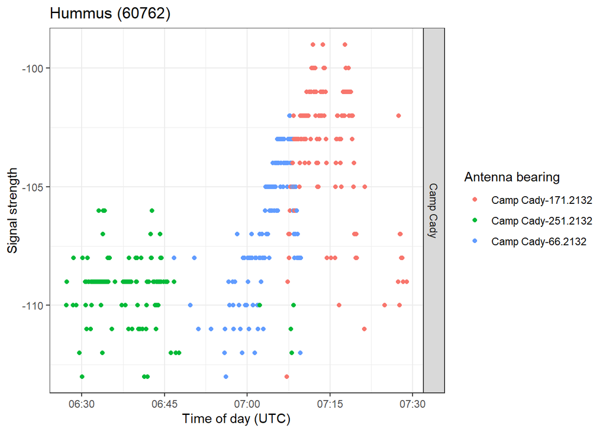

```r
# Run from here for plots
# Testing 1 day resulted in 0 records showed that the time_range cannot be 1 day.
# To make this work, we convert to POSIXCt datetime and add the right number of
# seconds.

df.rec_tags = df.rec.alltags %>%
  filter(motusTagID == tag_motus_id,
         ts >= as_datetime(time_range[1]),
         ts <= as_datetime(time_range[2]) + 1*24*60*60)
# (time_range = range(df.rec_tags$ts))
# Create scaling factor for later (between 0-1)
df.rec_tags$sig_scaled = (df.rec_tags$sig
  - max(df.rec_tags$sig)) /
  (max(df.rec_tags$sig) - min(df.rec_tags$sig))

rec_tags.sig  = df.rec_tags %>%
  ggplot(aes(x = ts, y = sig, col = as.factor(paste(recvDeployName,
                                                    antBearing,
                                                    sep = "-")))) +
  theme_bw() +
  geom_point() +
  labs(x = "Time of day (UTC)", y = "Signal strength",
       title = tag) +
  scale_color_discrete(name = "Antenna bearing") +
  facet_grid(recvDeployName ~ .)
rec_tags.sig
```

```r
ggsave(filename = paste(
  file_name_prefix, tag,
  as.character(as.Date(time_range[1])),
  "to",
  as.character(as.Date(time_range[2])),
  ".pdf", sep = "_"),
  device = "pdf",
  width = 8, height = 5,
  units = "in")

ggsave(filename = paste(
  file_name_prefix, tag,
  as.character(as.Date(time_range[1])),
  "to",
  as.character(as.Date(time_range[2])),
  ".jpg", sep = "_"),
  device = "jpg",
  width = 8, height = 5,
  units = "in")
```